# Results

## Preprocessing

### Data cleaning

All dataframes were checked for NAs, which were subsequently deleted. Genes with a variance lower than 0.1 were removed to reduce dimensionality, as they contribute very little to the overall variance of the data set and are most likely house-keeping genes. Doing so, the number of genes in the pan-caner data set was reduced from 60,000 to approximately 19,000 genes.

The low-variance filtering of the THCA data set was done in a similar way. Genes with a lower variance than 0.06 were deleted in the tumor tissue and the normal tissue data. This resulted in a reduction from approximately 20,000 genes to 15,000 genes in both data frames.

### Biotype filtering

To reduce dimensionality further, we determined the biotypes of the hallmark pathway genes, which was almost exclusively protein coding. To match this, only protein coding pathways were kept in all expression data sets for further analysis. The biotypes of our genes were retrieved using the `biomart::getBM()` function from the biomart package [@biomart].

### Pathway selection

The pathways from the MSigDB database were first aligned with the genes in our expression data [@msigdb]. Only pathways with a coverage of over 99% were kept. To avoid biases during enrichment analysis jaccard indices between hallmark pathways and MSigDB pathways were computed and pathways with a high similarity were removed.

## Descriptive analysis

### Mean-variance plot of TCGA expression data shows highly variant genes

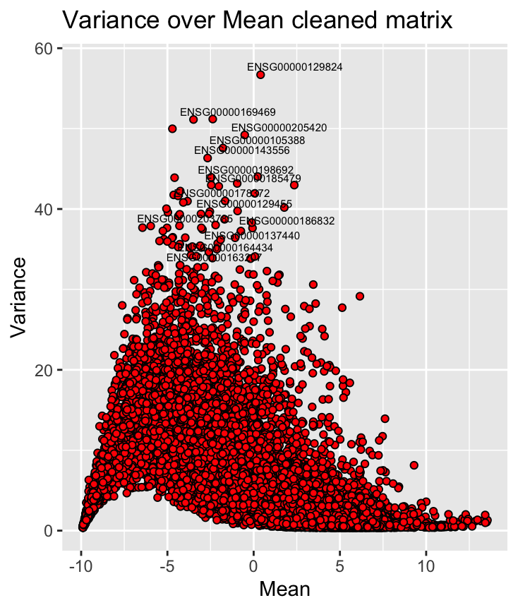

Mean-variance plot of cleaned TCGA expression data. Y-axis shows variance of a gene expression, x-axis shows the log2 mean of a gene expression. Genes with variance greater 33 are labelled with their ENSEMBL-ID

### Significantly up- and down regulated genes in THCA obtained from volcano plots

To determine those genes that are up- or down-regulated in THCA, the expression data from tumor tissue was compared to the data from normal tissue by mean log2 fold change. Associated p-Values were comuted with a Wilcoxon rank sum test. (Figure @ref(fig:showvolcanoplot)). The significance level adjusted to 1.755e-06 with a Bonferrioni adjustment.

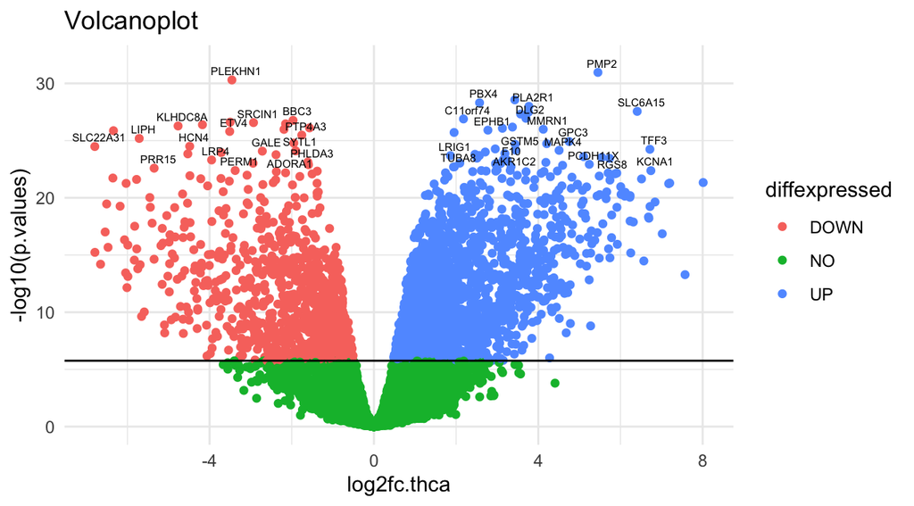

Volcano plot of THCA expression data. Downregulated genes are colored red, upregulated genes blue. Not significantly altered genes are colored green. Most significantly altered genes are labelled with their gene symbol

## Pan cancer analysis

### GSVA of TCGA expression data reveals four clusters of cancer types

Pathways, which are important for nucleus import and export like Nasopharygeal carcinoma (NPC) and Ran shuttle pathways, as well as pathways for transcription regulaturs in embryonic stem cells are down-regulated in glioblastoma and adenocarcinoma. However, these pathways are up-regulated in all other histological types. This seperation into two clusters is in line with the research of Ben-Porath et al., that shows an embryonic stem cell-like gene expression only in poorly differentiated tumors, such as leukemia [@result5]. In that way it could be conluded that the differentation stage of a tumor correlates with pathway activty specific to certain histological types @ref(fig:meanexp).

Another observation is the clustering of glioblastoma. Pathways initiating neurogenesis and pathways linked to differentiation of the neural crest are up-regulated only in glioblastoma [@result6]. Two other pathways, that are up-regulated in glioblastoma cells are pathways linked to the activity of tyrosine kinases. The up-regulation of tyrosine kinases promote cell growth and proliferation. [@cell]. Taken together these two observations are in line with the expected high proliferation rate commonly found in glioblastoma.

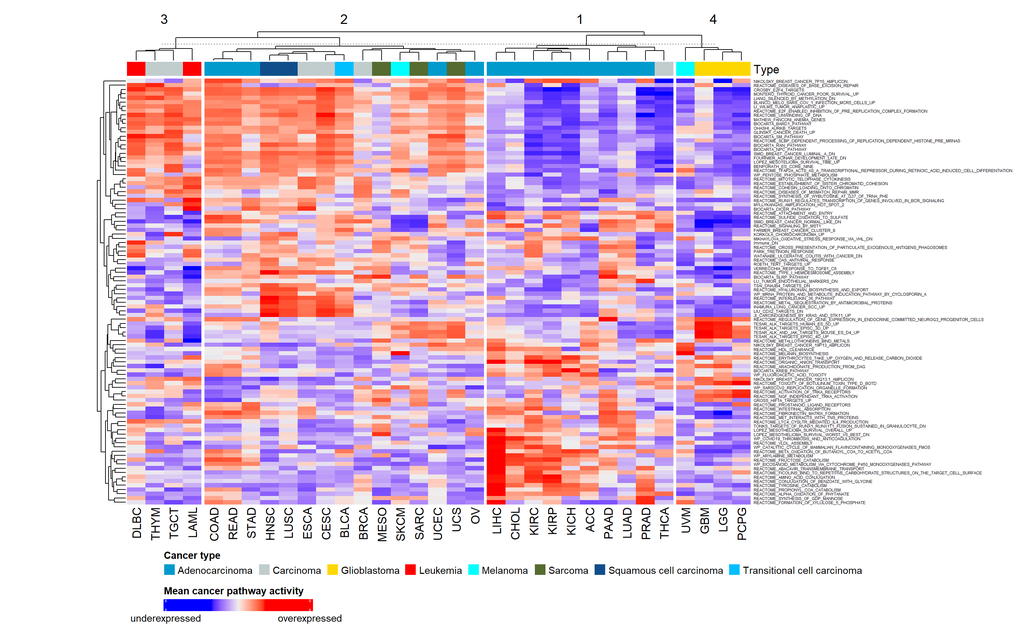

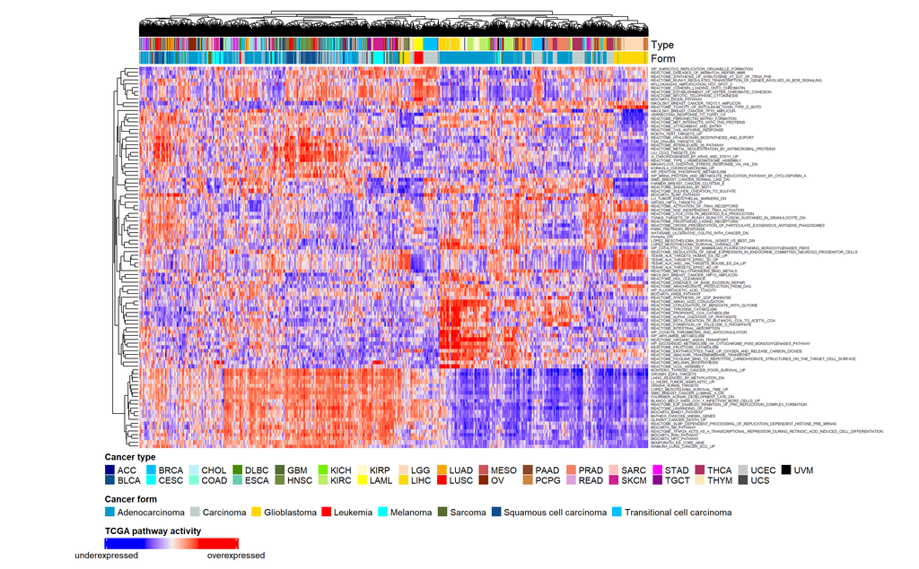

### Dimension reduction of GSVA pan-cancer data reveals clusters in pathway activity

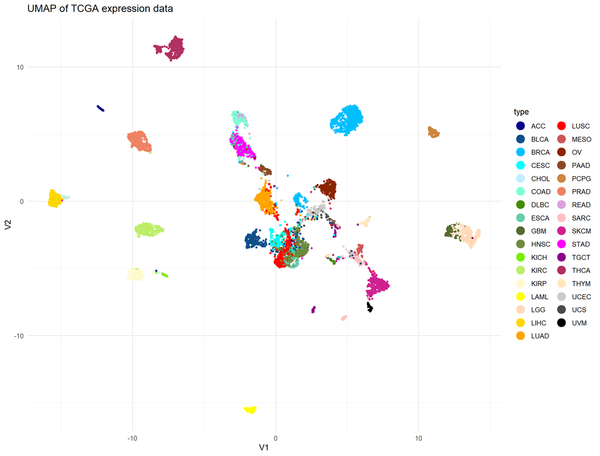

UMAP of TCGA pathway activity, colored by tumor type

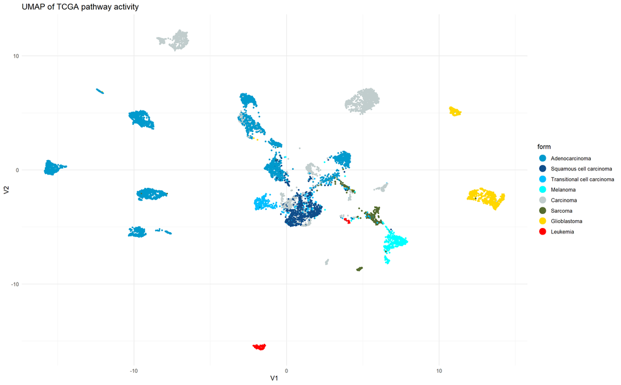

UMAP of TCGA pathway activity, colored by histological type

## Focused analysis

### GSVA on THCA expression data reveals pathways driving thyroid carcinogenesis.

To grasp a general overview of the differences in pathway activity between THCA and homeostatic thyroid tissue, GSVA was performed for the THCA expression data. Then, changes in pathway activity were computed by log2 fold change and the respective p-values were computed by a Wilcoxon rank-sum test. The most significantly altered pathways were then characterized. @ref(fig:THCAvolcano) Most prominently among them were pathways linked to proliferative signaling such as upregulation of p53 inhibitory proteins and hedgehog pathway activating Gli proteins. Further, the alpha6beta4 integrin signaling pathway and associated pathways such as IL-36 signaling and Typ I hemidesmosome synthesis were significantly enhanced in THCA. These findings are consistent with previous studies that linked alpha6beta4 signaling to the development of aggressive forms of thyroid cancer [@result4,@result3]. Also, oncogenic signaling pathways commonly associated with different cancer types were significantly upregulated in THCAs. Among them, we observed ERBB2 and MST1 signaling commonly found in breast cancer. A role for MSP/Ron in breast cancer has recently been elucidated, wherein this pathway regulates tumor growth, angiogenesis and metastasis [@result2].

Further, signaling through the EWSR1/FLI1-fusion protein was significantly upregulated in THCA. Lastly, THCAs showed downregulation of non-histone protein methylation. This process was identified as an import modulator of intracellular signaling by the MAPK, WNT, BMP, Hippo, and JAK/STAT pathways and might play an important role as a driver of carcinogenesis in THCA [@result1]. Together these findings give a general overview of mechanisms driving carcinogenesis in THCA. However, no information about possible THCA subtypes or differences in patway activity between patients can be obtained from this data.

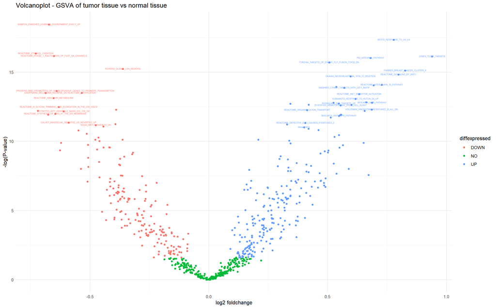

Volcano plot of THCA pathway activity. Downregulated pathways are colored red, upregulated pathways blue. Not significantly altered pathways are colored green. Most significantly altered pathways are labelled with their name.

### Pan-cancer data GSVA reveals three subtypes of THCA altering in proliferative signaling.

To investigate potential subtypes of THCA, the respective samples were taken from the pan-cancer GSVA data. The optimal number of clusters was determined by an elbow plot and subsequent K-means clustering revealed a total of three subtypes in THCA @ref(fig:THCAhm). This is consistent with the three clusters of THCA observed in the full pan-cancer GSVA data. The follicular histological type was enriched in cluster B, with no tall cell types present in this cluster. Judging from histological type alone no difference in clusters A and C was observed. Most significant changes in pathway activity were observed in pathways concerning proliferative signaling. In comparison with all other tumor types, cluster A displayed high activity of RAS, JAK/STAT and EWSR1/FL1-fusion mediated signaling as well as elevated signatures associated with carcinogenesis driven by alpha6beta4 activity. In contrast, these pathways were downregulated in cluster B, with it showing elevated activity in mTOR, MAPK, PI3K, and EGFR signaling cascades. Cluster C was found to upregulate all the aforementioned forms of proliferative signaling. All clusters showed a homogenous upregulation of hedgehog, ERBB2, and MST1 pathway activity. Regarding immune response, cluster C showed no significant alterations in the respective hallmark pathways, however, these pathways were downregulated in both clusters A and B. With this data, we can identify two seemingly different forms of proliferative signaling driving carcinogenesis in THCA. These forms can either occur separately as in the case of clusters A and B or combined as for cluster C.

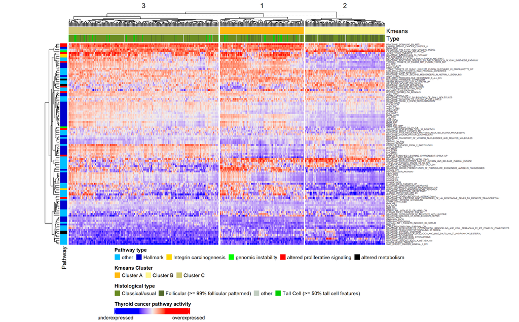

### THCA subtypes do not differ in their metabolism.

To investigate how the identified subtypes compare to homeostatic thyroid tissue, GSEA was performed for the THCA data. Consistent with the pan-cancer analysis of THCA data, k-means clustering obtained three different clusters in pathway activity – verified as the optimal number of clusters via an elbow plot. All clusters showed a similar change in metabolism @ref(fig:THCAhmGSEA). Katabolic pathways are downregulated whereas anabolic pathways e.g., fatty acid synthesis show increased activity in comparison with normal tissue. These changes in metabolic activity are in line with the Warburg effect. Further, the results seem consistent with the proliferative signaling activities found previously. Alpha6beta4, RAS, JAK/STAT, and EWSR1/FL1-fusion mediated signaling is upregulated in clusters one and three with low expression in cluster two. However, the expected upregulation of mTOR, MAPK, PI3K, and EGFR signaling in clusters two and three was observed only in some samples. Regarding, immune response the expression profiles are again consistent with differences observed in the GSVA pan-cancer data: Both clusters one and two show a lower immune response compared to cluster three. From these GSEA results, we can conclude that the three subtypes of THCA differ in carcinogenesis and associated immune response but share a similar metabolism consistent with the Warburg effect.

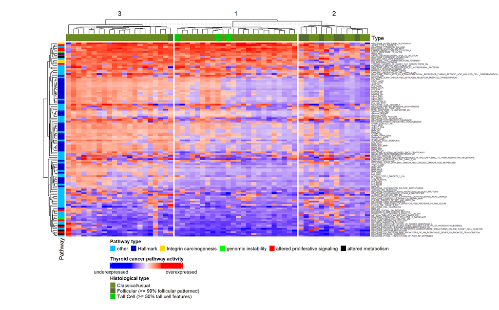

## Regression analysis of THCA pathway activity

Regression of the REACTOME_INTERLEUKIN_36_PATHWAY gene set showed mixed results. After multiple testing an architecture with two hidden layers with 10 and 20 neurons respectively at ` set.seed(50) ` was shown to produce the best results for neuronal network regression. Among the tested models, the neuronal network performed best on the test data with a mean squared error (MSE) of 0.06. However, the linear regression model failed to predict the data accurately (MSE = 0.62). Repeated linear regression with just pathways contributing significantly to the result the performance was enhanced (MSE = 0.40), however, remained worse than a null model (MSE = +0.22). @ref(fig:reg) Comparison of the MSE on test an training data reveals, that linear model is highly overfitted (ΔMSE = +0.55) with the linear model with significant pathways fitting slightly better (ΔMSE = +0.23) to the data. Our null model displayed an good, yet slightly underfitted performance with ΔMSE = -0.08. With a ΔMSE = +0.009 the neuronal network shows a perfect fit.

A comparison of the four regression models via the F-test function `var.test()` showed a significant improvement of the neuronal network compared to all other models. All other models showed no significant differences in their performance @ref(fig:reg) compared to each other. From this data, we can conclude that a neuronal network is the best choice for most accurately predicting IL-36 pathway activity in our test data.

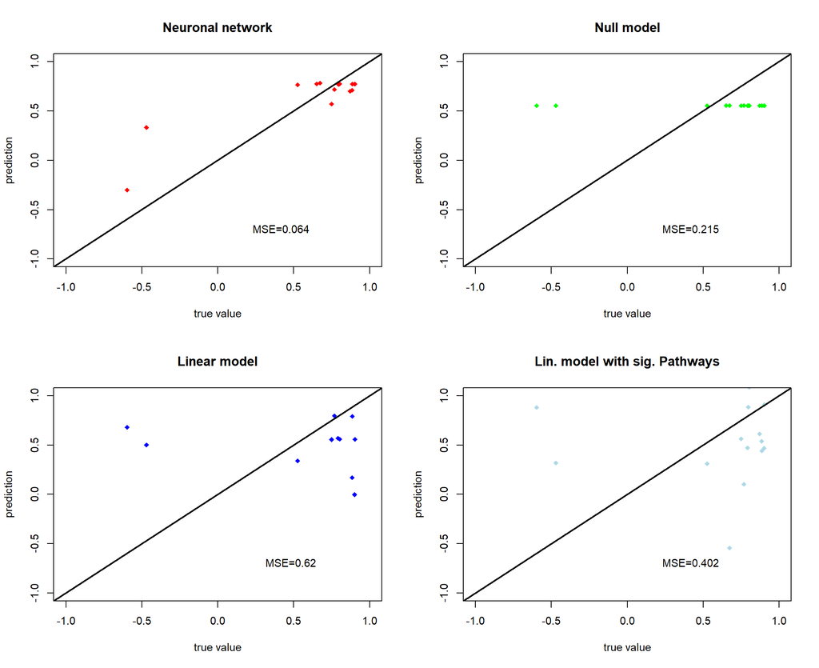

Regression results for various models on THCA GSEA test data. True values are plotted against predicted values, black slope indicate a perfect prediction.

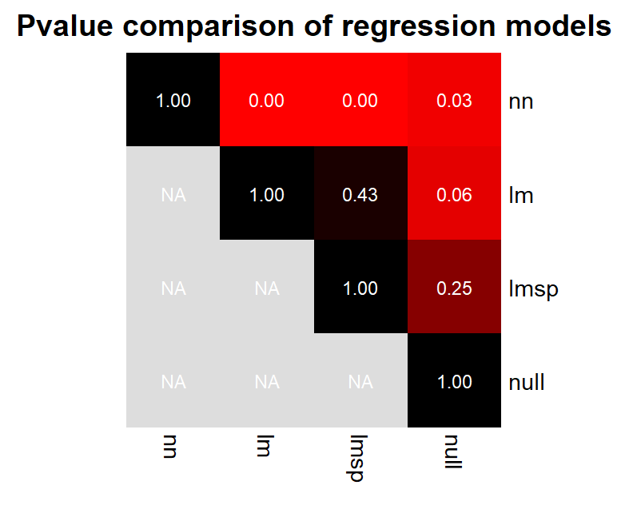

F-test comparison of various regression models. p-values are obtained from a two-sided variance test and displayed as heatmap. nn = neuronal network, lm = linear regression, lmsp = linear regression with only significant pathways, null = null model.